# Supplement

Ebeling et. al

2024-03-25

## Load data and preliminaries

### Miscellaneous for plotting

### Read in data

## Detection distance model

## Predict detection distance

We predicted detection distance by:

1. for both sexes based on mean flux of opposite sex of same size and measured eye diameter
2. based on mean flux of opposite sex and an eye diameter predicted by female eye size.

### Both sexes based on mean flux of mature individual of opposite sex

### Difference in detenction distance of males with and without lens sexual dimorphism ($\Delta r_{male}$)

## Regression modeling and model selection

### Flux models

ANOVA results of best-fitting flux model for M. niger

| term | df | sumsq | meansq | statistic | p.value |
| --- | --- | --- | --- | --- | --- |
| log(sl) | 1 | 222.34106 | 222.34106 | 40.93209 | 0.0000002 |
| sex | 1 | 186.10479 | 186.10479 | 34.26114 | 0.0000009 |
| log(sl):sex | 1 | 64.47253 | 64.47253 | 11.86913 | 0.0014066 |
| Residuals | 38 | 206.41412 | 5.43195 |  |  |

ANOVA results of best-fitting flux model for P. guernei

| term | df | sumsq | meansq | statistic | p.value |
| --- | --- | --- | --- | --- | --- |
| log(sl) | 1 | 48.50590 | 48.5059014 | 58.82218 | 0.0000000 |
| sex | 1 | 69.53752 | 69.5375174 | 84.32681 | 0.0000000 |
| log(sl):sex | 1 | 11.84135 | 11.8413508 | 14.35978 | 0.0003614 |
| Residuals | 58 | 47.82792 | 0.8246193 |  |  |

### Lens diameter models

ANOVA results of best-fitting lens-diameter model for M. niger

| term | df | sumsq | meansq | statistic | p.value |
| --- | --- | --- | --- | --- | --- |
| sex | 1 | 9.00e-07 | 9.00e-07 | 22.42112 | 0.0000288 |
| sl | 1 | 2.23e-05 | 2.23e-05 | 583.96731 | 0.0000000 |
| sex:sl | 1 | 5.00e-07 | 5.00e-07 | 13.49389 | 0.0007171 |
| Residuals | 39 | 1.50e-06 | 0.00e+00 |  |  |

ANOVA results of best-fitting lens-diamter model for P. guernei

| term | df | sumsq | meansq | statistic | p.value |
| --- | --- | --- | --- | --- | --- |
| sex | 1 | 1.8e-06 | 1.8e-06 | 21.855529 | 0.0000180 |
| sl | 1 | 6.2e-06 | 6.2e-06 | 75.462319 | 0.0000000 |
| sex:sl | 1 | 2.0e-07 | 2.0e-07 | 2.991944 | 0.0889985 |
| Residuals | 58 | 4.7e-06 | 1.0e-07 |  |  |

### Detection distance models

ANOVA results of best-fitting detection distance model for M. niger

| term | df | sumsq | meansq | statistic | p.value |
| --- | --- | --- | --- | --- | --- |
| log(sl) | 1 | 6.4501020 | 6.4501020 | 1113.7969 | 0 |
| sex | 1 | 5.0240570 | 5.0240570 | 867.5489 | 0 |
| log(sl):sex | 1 | 1.1900129 | 1.1900129 | 205.4902 | 0 |
| Residuals | 39 | 0.2258526 | 0.0057911 |  |  |

ANOVA results of best-fitting detection distance model for P. guernei

| term | df | sumsq | meansq | statistic | p.value |
| --- | --- | --- | --- | --- | --- |
| log(sl) | 1 | 16.0409741 | 16.0409741 | 1119.5273 | 0 |
| sex | 1 | 6.1596901 | 6.1596901 | 429.8954 | 0 |
| log(sl):sex | 1 | 0.8625651 | 0.8625651 | 60.1999 | 0 |
| Residuals | 58 | 0.8310441 | 0.0143283 |  |  |

### Difference in male detection distance with and without a dimorphic eye ($\Delta r_{male}$)

```
##
##  One Sample t-test
##
## data:  det_diff %>% filter(species == "M. niger") %>% pull(det_diff_)
## t = 5.2762, df = 24, p-value = 1.034e-05
## alternative hypothesis: true mean is greater than 0
## 95 percent confidence interval:
##  1.064532      Inf
## sample estimates:
## mean of x
##  1.575363
```

```
##
##  One Sample t-test
##
## data:  det_diff %>% filter(species == "P. guernei") %>% pull(det_diff_)
## t = 5.3909, df = 29, p-value = 4.281e-06
## alternative hypothesis: true mean is greater than 0
## 95 percent confidence interval:
##  0.9512102       Inf
## sample estimates:
## mean of x
##  1.389002
```

### Model selection

### Flux AIC table

A positively allometric model fits best for both species.

```
##  log(sl)
## 3.915213
```

```
##  log(sl)
## 2.089499
```

Model fitting metrics for photophore flux regressions in both species

species

sex

sl

sex:sl

log(sl)

log(sl):sex

df

AICc

delta

weight

M. niger

3.915213

5

197.7305

0.000000

9.880533e-01

M. niger

12.361229

4

206.5612

8.830687

1.194596e-02

M. niger

11.800601

3

226.0762

28.345681

6.911843e-07

P. guernei

2.089499

5

170.9293

0.000000

9.965729e-01

P. guernei

4.416062

4

182.2745

11.345197

3.427132e-03

ANOVA table for the best fitting flux regression model for M. niger

|  | Df | Sum Sq | Mean Sq | F value | Pr(>F) |
| --- | --- | --- | --- | --- | --- |
| log(sl) | 1 | 222.34106 | 222.34106 | 40.93209 | 0.0000002 |
| sex | 1 | 186.10479 | 186.10479 | 34.26114 | 0.0000009 |
| log(sl):sex | 1 | 64.47253 | 64.47253 | 11.86913 | 0.0014066 |
| Residuals | 38 | 206.41412 | 5.43195 |  |  |

ANOVA table for the best fitting flux regression model for P. guernei

|  | Df | Sum Sq | Mean Sq | F value | Pr(>F) |
| --- | --- | --- | --- | --- | --- |
| log(sl) | 1 | 48.50590 | 48.5059014 | 58.82218 | 0.0000000 |
| sex | 1 | 69.53752 | 69.5375174 | 84.32681 | 0.0000000 |
| log(sl):sex | 1 | 11.84135 | 11.8413508 | 14.35978 | 0.0003614 |
| Residuals | 58 | 47.82792 | 0.8246193 |  |  |

### Lens AIC Tables

An isometric, linear model fits best for both species.

Model fitting metrics for photophore lens-diameter regressions in both species

species

sex

sl

sex:sl

log(sl)

log(sl):sex

df

AICc

delta

weight

M. niger

0.0004085

5

-605.0539

0.0000000

9.939617e-01

M. niger

0.0003398

4

-594.8460

10.2078237

6.036274e-03

M. niger

0.0003381

3

-578.8244

26.2294870

2.003129e-06

P. guernei

0.0001322

5

-828.8388

0.0000000

5.925225e-01

P. guernei

0.0001694

4

-828.0900

0.7488505

4.074685e-01

P. guernei

0.0001613

3

-806.6525

22.1863182

9.015858e-06

ANOVA table for the best fitting lens-diameter regression model for M. niger

|  | Df | Sum Sq | Mean Sq | F value | Pr(>F) |
| --- | --- | --- | --- | --- | --- |
| sex | 1 | 9.00e-07 | 9.00e-07 | 22.42112 | 0.0000288 |
| sl | 1 | 2.23e-05 | 2.23e-05 | 583.96731 | 0.0000000 |
| sex:sl | 1 | 5.00e-07 | 5.00e-07 | 13.49389 | 0.0007171 |
| Residuals | 39 | 1.50e-06 | 0.00e+00 |  |  |

ANOVA table for the best fitting lens-diameter regression model for P. guernei

|  | Df | Sum Sq | Mean Sq | F value | Pr(>F) |
| --- | --- | --- | --- | --- | --- |
| sex | 1 | 1.8e-06 | 1.8e-06 | 21.855529 | 0.0000180 |
| sl | 1 | 6.2e-06 | 6.2e-06 | 75.462319 | 0.0000000 |
| sex:sl | 1 | 2.0e-07 | 2.0e-07 | 2.991944 | 0.0889985 |
| Residuals | 58 | 4.7e-06 | 1.0e-07 |  |  |

### Detection-distance AIC Tables

A negatively allometric fits best for both species.

```
##  (Intercept)      log(sl)         sexM log(sl):sexM
##    -2.906179     3.085696     3.580588    -1.790797
```

```
##  (Intercept)      log(sl)         sexM log(sl):sexM
##    -3.304085     2.782284     1.698683    -1.079176
```

Model fitting metrics for photophore detection distance regressions in both species

species

sex

sl

sex:sl

log(sl)

log(sl):sex

df

AICc

delta

weight

M. niger

3.085696

5

-92.05979

0.00000

1.000000e+00

P. guernei

2.782284

5

-80.33702

0.00000

1.000000e+00

P. guernei

2.154355

4

-38.56677

41.77025

8.505603e-10

ANOVA table for the best fitting detection-distance regression model for M. niger

|  | Df | Sum Sq | Mean Sq | F value | Pr(>F) |
| --- | --- | --- | --- | --- | --- |
| log(sl) | 1 | 6.4501020 | 6.4501020 | 1113.7969 | 0 |
| sex | 1 | 5.0240570 | 5.0240570 | 867.5489 | 0 |
| log(sl):sex | 1 | 1.1900129 | 1.1900129 | 205.4902 | 0 |
| Residuals | 39 | 0.2258526 | 0.0057911 |  |  |

ANOVA table for the best fitting detection-distance regression model for P. guernei

|  | Df | Sum Sq | Mean Sq | F value | Pr(>F) |
| --- | --- | --- | --- | --- | --- |
| log(sl) | 1 | 16.0409741 | 16.0409741 | 1119.5273 | 0 |
| sex | 1 | 6.1596901 | 6.1596901 | 429.8954 | 0 |
| log(sl):sex | 1 | 0.8625651 | 0.8625651 | 60.1999 | 0 |
| Residuals | 58 | 0.8310441 | 0.0143283 |  |  |

### Effect of Larger Eye Size on Detection difference

## Figures

### Figure 1

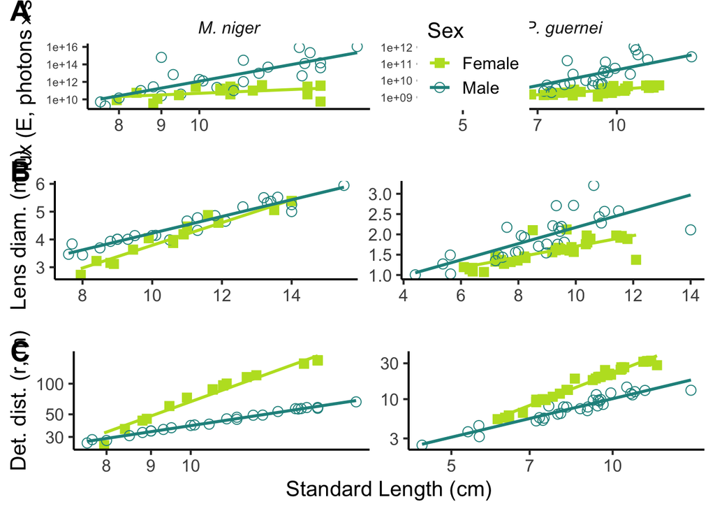

### Figure 3

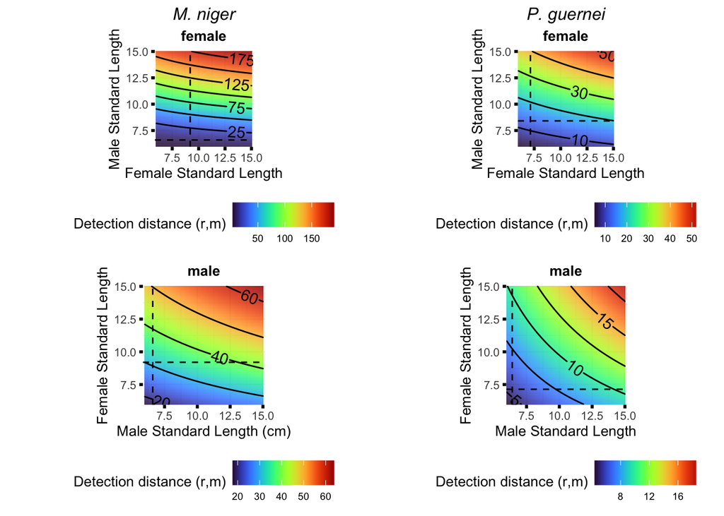

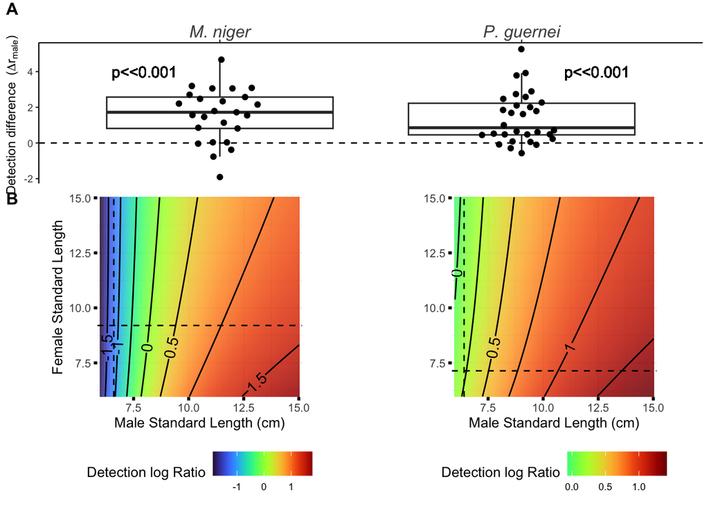

### Summary stats mentioned in paper

```
## # A tibble: 4 × 4
## # Groups:   sex [2]
##   sex   genus        `min(detect)` `max(detect)`
##   <chr> <chr>                <dbl>         <dbl>
## 1 F     Malacosteus          24.9          170.
## 2 F     Photostomias          5.42          32.5
## 3 M     Malacosteus          26.1           66.3
## 4 M     Photostomias          2.44          14.5
```

### Print Figures

#### Figures in text

#### Specimen table

#### AIC tables